# Jupyter Notebook Demo

## Analyzing a new website's data

## Required imports

```python
import pandas as pd
import numpy as np
import matplotlib.pyplot as plt
import csv
```

## Importing data into the notebook from a csv file

```python
rawdata = []
with open ("/Users/edouardasmar/serviceboxanalytics.csv", "rb") as csvfile:
    reader = csv.DictReader(csvfile, dialect="excel")
    for row in reader:
        rawdata.append(row)
```

### Moving the data into a pandas Data Frame

- Data frames are equivalent to tables in languages like SQL

```python
df = pd.DataFrame(rawdata)
```

### The Data Frame:

- In SQL: `use df; select top * from df;`

```python
df
```

|  |  | bounces | date | daysSinceLastSession | entrances | exitPagePath | newUsers | pageLoadTime | pagePath | pageviews | sessionCount | sessionDurationBucket | sessions | sessionsPerUser | timeOnPage | userType | users |
| --- | --- | --- | --- | --- | --- | --- | --- | --- | --- | --- | --- | --- | --- | --- | --- | --- | --- |
| 0 | 1 | 3 | 2016-06-18 | 0 | 3 | / | 3 | 0 | / | 3 | 1 | 0 | 3 | 1 | 0 | New Visitor | 3 |
| 1 | 2 | 1 | 2016-06-18 | 0 | 1 | /tourist-attractions | 1 | 0 | /tourist-attractions | 1 | 1 | 0 | 1 | 1 | 0 | New Visitor | 1 |
| 2 | 3 | 1 | 2016-06-18 | 1 | 1 | / | 0 | 0 | / | 1 | 4 | 0 | 1 | 1 | 0 | Returning Visitor | 1 |
| 3 | 4 | 0 | 2016-06-18 | 0 | 1 | /standardlesothobank | 0 | 0 | / | 1 | 60 | 11 | 1 | 1 | 11 | Returning Visitor | 1 |
| 4 | 5 | 0 | 2016-06-18 | 0 | 0 | /standardlesothobank | 0 | 0 | /standardlesothobank | 1 | 60 | 11 | 0 | 0 | 0 | Returning Visitor | 1 |
| 5 | 6 | 0 | 2016-06-18 | 0 | 1 | /mpesa | 0 | 0 | / | 2 | 140 | 11560 | 1 | 1 | 382 | Returning Visitor | 1 |
| 6 | 7 | 0 | 2016-06-18 | 0 | 0 | /mpesa | 0 | 0 | /accommodation | 1 | 140 | 11560 | 0 | 0 | 93 | Returning Visitor | 1 |
| 7 | 8 | 0 | 2016-06-18 | 0 | 0 | /mpesa | 0 | 0 | /contacts/emergency | 1 | 140 | 11560 | 0 | 0 | 31 | Returning Visitor | 1 |
| 8 | 9 | 0 | 2016-06-18 | 0 | 0 | /mpesa | 0 | 0 | /mpesa | 30 | 140 | 11560 | 0 | 0 | 7182 | Returning Visitor | 1 |
| 9 | 10 | 0 | 2016-06-18 | 0 | 0 | /mpesa | 0 | 0 | /standardlesothobank | 9 | 140 | 11560 | 0 | 0 | 2201 | Returning Visitor | 1 |
| 10 | 11 | 0 | 2016-06-18 | 0 | 0 | /mpesa | 0 | 0 | /tourist-attractions | 18 | 140 | 11560 | 0 | 0 | 1677 | Returning Visitor | 1 |
| 11 | 12 | 0 | 2016-06-18 | 11 | 0 | /tourist-attractions | 0 | 0 | /accommodation | 1 | 4 | 207 | 0 | 0 | 134 | Returning Visitor | 1 |
| 12 | 13 | 0 | 2016-06-18 | 11 | 1 | /tourist-attractions | 0 | 0 | /tourist-attractions | 2 | 4 | 207 | 1 | 1 | 73 | Returning Visitor | 1 |
| 13 | 14 | 0 | 2016-06-18 | 0 | 0 | /accommodation | 0 | 0 | /accommodation | 1 | 1 | 86 | 0 | 0 | 0 | New Visitor | 1 |
| 14 | 15 | 0 | 2016-06-18 | 0 | 1 | /accommodation | 1 | 0 | /tourist-attractions | 1 | 1 | 86 | 1 | 1 | 86 | New Visitor | 1 |
| 15 | 16 | 0 | 2016-06-18 | 0 | 0 | /standardlesothobank | 0 | 0 | /standardlesothobank | 1 | 141 | 87 | 0 | 0 | 0 | Returning Visitor | 1 |
| 16 | 17 | 0 | 2016-06-18 | 0 | 1 | /standardlesothobank | 0 | 0 | /tourist-attractions | 1 | 141 | 87 | 1 | 1 | 87 | Returning Visitor | 1 |
| 17 | 18 | 1 | 2016-06-19 | 0 | 1 | / | 1 | 0 | / | 1 | 1 | 0 | 1 | 1 | 0 | New Visitor | 1 |
| 18 | 19 | 1 | 2016-06-19 | 0 | 1 | /tourist-attractions | 1 | 0 | /tourist-attractions | 1 | 1 | 0 | 1 | 1 | 0 | New Visitor | 1 |
| 19 | 20 | 1 | 2016-06-19 | 0 | 1 | /mpesa | 0 | 0 | /mpesa | 1 | 62 | 0 | 1 | 1 | 0 | Returning Visitor | 1 |
| 20 | 21 | 0 | 2016-06-19 | 1 | 1 | /mpesa | 0 | 0 | / | 2 | 143 | 515 | 1 | 1 | 117 | Returning Visitor | 1 |
| 21 | 22 | 0 | 2016-06-19 | 1 | 0 | /mpesa | 0 | 0 | /mpesa | 2 | 143 | 515 | 0 | 0 | 398 | Returning Visitor | 1 |
| 22 | 23 | 0 | 2016-06-19 | 0 | 1 | /mpesa | 0 | 0 | / | 1 | 144 | 5768 | 1 | 1 | 16 | Returning Visitor | 1 |
| 23 | 24 | 0 | 2016-06-19 | 0 | 0 | /mpesa | 0 | 0 | /mpesa | 31 | 144 | 5768 | 0 | 0 | 5753 | Returning Visitor | 1 |
| 24 | 25 | 0 | 2016-06-19 | 1 | 1 | /mpesa | 0 | 0 | / | 2 | 61 | 727 | 1 | 1 | 22 | Returning Visitor | 1 |
| 25 | 26 | 0 | 2016-06-19 | 1 | 0 | /mpesa | 0 | 0 | /accommodation | 4 | 61 | 727 | 0 | 0 | 159 | Returning Visitor | 1 |
| 26 | 27 | 0 | 2016-06-19 | 1 | 0 | /mpesa | 0 | 0 | /mpesa | 3 | 61 | 727 | 0 | 0 | 546 | Returning Visitor | 1 |
| 27 | 28 | 2 | 2016-06-20 | 0 | 2 | / | 2 | 0 | / | 2 | 1 | 0 | 2 | 1 | 0 | New Visitor | 2 |
| 28 | 29 | 1 | 2016-06-20 | 0 | 1 | /mpesa | 1 | 0 | /mpesa | 1 | 1 | 0 | 1 | 1 | 0 | New Visitor | 1 |
| 29 | 30 | 1 | 2016-06-20 | 0 | 1 | /tourist-attractions | 0 | 0 | /tourist-attractions | 1 | 2 | 0 | 1 | 1 | 0 | Returning Visitor | 1 |
| ... | ... | ... | ... | ... | ... | ... | ... | ... | ... | ... | ... | ... | ... | ... | ... | ... | ... |
| 1629 | 1630 | 0 | 2016-07-18 | 14 | 1 | /ecocash | 0 | 0 | / | 2 | 14 | 908 | 1 | 1 | 182 | Returning Visitor | 1 |
| 1630 | 1631 | 0 | 2016-07-18 | 14 | 0 | /ecocash | 0 | 0 | /ecocash | 2 | 14 | 908 | 0 | 0 | 251 | Returning Visitor | 1 |
| 1631 | 1632 | 0 | 2016-07-18 | 14 | 0 | /ecocash | 0 | 0 | /mpesa | 3 | 14 | 908 | 0 | 0 | 143 | Returning Visitor | 1 |
| 1632 | 1633 | 0 | 2016-07-18 | 14 | 0 | /ecocash | 0 | 0 | /police | 1 | 14 | 908 | 0 | 0 | 251 | Returning Visitor | 1 |
| 1633 | 1634 | 0 | 2016-07-18 | 14 | 0 | /ecocash | 0 | 0 | /standardlesothobank | 1 | 14 | 908 | 0 | 0 | 10 | Returning Visitor | 1 |
| 1634 | 1635 | 0 | 2016-07-18 | 14 | 0 | /ecocash | 0 | 0 | /telephone-taxis | 1 | 14 | 908 | 0 | 0 | 40 | Returning Visitor | 1 |
| 1635 | 1636 | 0 | 2016-07-18 | 14 | 0 | /ecocash | 0 | 0 | /tourist-attractions | 1 | 14 | 908 | 0 | 0 | 31 | Returning Visitor | 1 |
| 1636 | 1637 | 0 | 2016-07-18 | 0 | 1 | /emergency | 1 | 0 | / | 4 | 1 | 909 | 1 | 1 | 144 | New Visitor | 1 |
| 1637 | 1638 | 0 | 2016-07-18 | 0 | 0 | /emergency | 0 | 0 | /accommodation | 1 | 1 | 909 | 0 | 0 | 49 | New Visitor | 1 |
| 1638 | 1639 | 0 | 2016-07-18 | 0 | 0 | /emergency | 0 | 0 | /ecocash | 1 | 1 | 909 | 0 | 0 | 87 | New Visitor | 1 |
| 1639 | 1640 | 0 | 2016-07-18 | 0 | 0 | /emergency | 0 | 0 | /emergency | 1 | 1 | 909 | 0 | 0 | 0 | New Visitor | 1 |
| 1640 | 1641 | 0 | 2016-07-18 | 0 | 0 | /emergency | 0 | 0 | /mpesa | 1 | 1 | 909 | 0 | 0 | 189 | New Visitor | 1 |
| 1641 | 1642 | 0 | 2016-07-18 | 0 | 0 | /emergency | 0 | 0 | /police | 2 | 1 | 909 | 0 | 0 | 81 | New Visitor | 1 |
| 1642 | 1643 | 0 | 2016-07-18 | 0 | 0 | /emergency | 0 | 0 | /standardlesothobank | 1 | 1 | 909 | 0 | 0 | 226 | New Visitor | 1 |
| 1643 | 1644 | 0 | 2016-07-18 | 0 | 0 | /emergency | 0 | 0 | /telephone-taxis | 1 | 1 | 909 | 0 | 0 | 67 | New Visitor | 1 |
| 1644 | 1645 | 0 | 2016-07-18 | 0 | 0 | /emergency | 0 | 0 | /tourist-attractions | 2 | 1 | 909 | 0 | 0 | 64 | New Visitor | 1 |
| 1645 | 1646 | 0 | 2016-07-18 | 0 | 1 | /tourist-attractions | 1 | 0 | / | 2 | 1 | 944 | 1 | 1 | 152 | New Visitor | 1 |
| 1646 | 1647 | 0 | 2016-07-18 | 0 | 0 | /tourist-attractions | 0 | 0 | /accommodation | 1 | 1 | 944 | 0 | 0 | 192 | New Visitor | 1 |
| 1647 | 1648 | 0 | 2016-07-18 | 0 | 0 | /tourist-attractions | 0 | 0 | /emergency | 1 | 1 | 944 | 0 | 0 | 51 | New Visitor | 1 |
| 1648 | 1649 | 0 | 2016-07-18 | 0 | 0 | /tourist-attractions | 0 | 0 | /mpesa | 1 | 1 | 944 | 0 | 0 | 255 | New Visitor | 1 |
| 1649 | 1650 | 0 | 2016-07-18 | 0 | 0 | /tourist-attractions | 0 | 0 | /police | 1 | 1 | 944 | 0 | 0 | 126 | New Visitor | 1 |
| 1650 | 1651 | 0 | 2016-07-18 | 0 | 0 | /tourist-attractions | 0 | 0 | /telephone-taxis | 1 | 1 | 944 | 0 | 0 | 25 | New Visitor | 1 |
| 1651 | 1652 | 0 | 2016-07-18 | 0 | 0 | /tourist-attractions | 0 | 0 | /tourist-attractions | 2 | 1 | 944 | 0 | 0 | 143 | New Visitor | 1 |
| 1652 | 1653 | 0 | 2016-07-18 | 0 | 1 | /accommodation | 1 | 8456 | / | 1 | 1 | 945 | 1 | 1 | 240 | New Visitor | 1 |
| 1653 | 1654 | 0 | 2016-07-18 | 0 | 0 | /accommodation | 0 | 10616 | /accommodation | 2 | 1 | 945 | 0 | 0 | 138 | New Visitor | 1 |
| 1654 | 1655 | 0 | 2016-07-18 | 0 | 0 | /accommodation | 0 | 5477 | /police | 1 | 1 | 945 | 0 | 0 | 477 | New Visitor | 1 |
| 1655 | 1656 | 0 | 2016-07-18 | 0 | 0 | /accommodation | 0 | 30794 | /tourist-attractions | 2 | 1 | 945 | 0 | 0 | 90 | New Visitor | 1 |
| 1656 | 1657 | 0 | 2016-07-18 | 0 | 1 | /accommodation | 1 | 0 | / | 1 | 1 | 96 | 1 | 1 | 25 | New Visitor | 1 |
| 1657 | 1658 | 0 | 2016-07-18 | 0 | 0 | /accommodation | 0 | 0 | /accommodation | 1 | 1 | 96 | 0 | 0 | 0 | New Visitor | 1 |
| 1658 | 1659 | 0 | 2016-07-18 | 0 | 0 | /accommodation | 0 | 0 | /police | 1 | 1 | 96 | 0 | 0 | 71 | New Visitor | 1 |

1659 rows × 17 columns

## dtypes allows you to check the types of each column in the data frame

```python
df.dtypes
```

```
                         object
bounces                  object
date                     object
daysSinceLastSession     object
entrances                object
exitPagePath             object
newUsers                 object
pageLoadTime             object
pagePath                 object
pageviews                object
sessionCount             object
sessionDurationBucket    object
sessions                 object
sessionsPerUser          object
timeOnPage               object
userType                 object
users                    object
dtype: object
```

## Use `head()` and `tail()` to see top 5 and bottom 5 results

```python
df.head()
```

|  |  | bounces | date | daysSinceLastSession | entrances | exitPagePath | newUsers | pageLoadTime | pagePath | pageviews | sessionCount | sessionDurationBucket | sessions | sessionsPerUser | timeOnPage | userType | users |
| --- | --- | --- | --- | --- | --- | --- | --- | --- | --- | --- | --- | --- | --- | --- | --- | --- | --- |
| 0 | 1 | 3 | 2016-06-18 | 0 | 3 | / | 3 | 0 | / | 3 | 1 | 0 | 3 | 1 | 0 | New Visitor | 3 |
| 1 | 2 | 1 | 2016-06-18 | 0 | 1 | /tourist-attractions | 1 | 0 | /tourist-attractions | 1 | 1 | 0 | 1 | 1 | 0 | New Visitor | 1 |
| 2 | 3 | 1 | 2016-06-18 | 1 | 1 | / | 0 | 0 | / | 1 | 4 | 0 | 1 | 1 | 0 | Returning Visitor | 1 |
| 3 | 4 | 0 | 2016-06-18 | 0 | 1 | /standardlesothobank | 0 | 0 | / | 1 | 60 | 11 | 1 | 1 | 11 | Returning Visitor | 1 |
| 4 | 5 | 0 | 2016-06-18 | 0 | 0 | /standardlesothobank | 0 | 0 | /standardlesothobank | 1 | 60 | 11 | 0 | 0 | 0 | Returning Visitor | 1 |

```python
df.tail()
```

|  |  | bounces | date | daysSinceLastSession | entrances | exitPagePath | newUsers | pageLoadTime | pagePath | pageviews | sessionCount | sessionDurationBucket | sessions | sessionsPerUser | timeOnPage | userType | users |
| --- | --- | --- | --- | --- | --- | --- | --- | --- | --- | --- | --- | --- | --- | --- | --- | --- | --- |
| 1654 | 1655 | 0 | 2016-07-18 | 0 | 0 | /accommodation | 0 | 5477 | /police | 1 | 1 | 945 | 0 | 0 | 477 | New Visitor | 1 |
| 1655 | 1656 | 0 | 2016-07-18 | 0 | 0 | /accommodation | 0 | 30794 | /tourist-attractions | 2 | 1 | 945 | 0 | 0 | 90 | New Visitor | 1 |
| 1656 | 1657 | 0 | 2016-07-18 | 0 | 1 | /accommodation | 1 | 0 | / | 1 | 1 | 96 | 1 | 1 | 25 | New Visitor | 1 |
| 1657 | 1658 | 0 | 2016-07-18 | 0 | 0 | /accommodation | 0 | 0 | /accommodation | 1 | 1 | 96 | 0 | 0 | 0 | New Visitor | 1 |
| 1658 | 1659 | 0 | 2016-07-18 | 0 | 0 | /accommodation | 0 | 0 | /police | 1 | 1 | 96 | 0 | 0 | 71 | New Visitor | 1 |

## Selection, group by and functions

- Selectng specific columns
- Group by and max

```python
df[['newUsers', 'date']].groupby('date').max()
```

| date | newUsers |
| --- | --- |
| 2016-06-18 | 3 |
| 2016-06-19 | 1 |
| 2016-06-20 | 2 |
| 2016-06-21 | 0 |
| 2016-06-22 | 1 |
| 2016-06-23 | 2 |
| 2016-06-24 | 1 |
| 2016-06-25 | 1 |
| 2016-06-26 | 1 |
| 2016-06-27 | 1 |
| 2016-06-28 | 1 |
| 2016-06-29 | 1 |
| 2016-06-30 | 1 |
| 2016-07-01 | 8 |
| 2016-07-02 | 1 |
| 2016-07-03 | 0 |
| 2016-07-04 | 3 |
| 2016-07-05 | 1 |
| 2016-07-06 | 2 |
| 2016-07-07 | 2 |
| 2016-07-08 | 2 |
| 2016-07-09 | 2 |
| 2016-07-10 | 2 |
| 2016-07-11 | 2 |
| 2016-07-12 | 4 |
| 2016-07-13 | 1 |
| 2016-07-14 | 1 |
| 2016-07-15 | 8 |
| 2016-07-16 | 8 |
| 2016-07-17 | 3 |
| 2016-07-18 | 22 |

## Changing types

- `astype(type=)`

```python
df[['entrances','bounces','newUsers','daysSinceLastSession','pageLoadTime', 'pageviews', 'timeOnPage','sessionDurationBucket', 'users', 'sessionCount', 'sessions', 'sessionsPerUser']] = df[['entrances','bounces','newUsers','daysSinceLastSession','pageLoadTime', 'pageviews', 'timeOnPage','sessionDurationBucket', 'users','sessionCount', 'sessions', 'sessionsPerUser']].astype(int)
```

```python
df.dtypes
```

```
                         object
bounces                   int64
date                     object
daysSinceLastSession      int64
entrances                 int64
exitPagePath             object
newUsers                  int64
pageLoadTime              int64
pagePath                 object
pageviews                 int64
sessionCount              int64
sessionDurationBucket     int64
sessions                  int64
sessionsPerUser           int64
timeOnPage                int64
userType                 object
users                     int64
dtype: object
```

## Creating sub-tables out of results

- Simply assign the results to a new variable
- In SQL: `select a.exitPagePath as exit, sum(a.entrances) as entrances from df as a group by exit`

```python
entrancesAndExits = df[['exitPagePath', 'entrances']].groupby('exitPagePath').sum()
entrancesAndExits
```

| exitPagePath | entrances |
| --- | --- |
| / | 217 |
| /accommodation | 45 |
| /contacts/emergency | 3 |
| /directions?end=-29.315504,27.489813 | 1 |
| /directions?end=-29.316257,27.478507 | 1 |
| /ecocash | 18 |
| /emergency | 16 |
| /mpesa | 27 |
| /police | 27 |
| /slideimages/ads/slide1.jpg | 1 |
| /standardlesothobank | 55 |
| /telephone-taxis | 13 |
| /tourism-attractions | 1 |
| /tourism/attractions | 1 |
| /tourist-attractions | 581 |

## Making a visualization

- Use the plot library by calling `.plot.[plotType]()`
- For the visualization to appear inline must call `%matplotlib inline`
- Say your boss asks:
  - What are common entry/exit points for the website?
  - How many times has each page been viewed?
  - Can make some sample visualizations to answer these questions

```python
%matplotlib inline
```

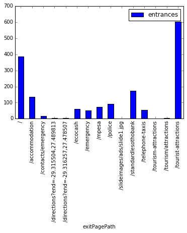

```python
entrancesAndPages = df[['exitPagePath', 'entrances']].groupby('exitPagePath').count()
entrancesAndPages.plot.bar()
```

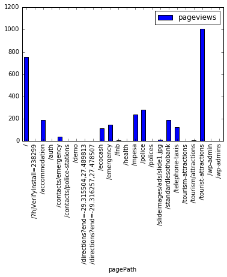

```python
pageViewsAndPages = df[['pagePath', 'pageviews']].groupby('pagePath').sum()
pageViewsAndPages.plot.bar()
```

## Your boss now asks:

- What regions and cities does traffic come from?
- How many new users each day?
- What devices and OSs are accessing the website?

## Let's walk through how to protype answers to these questions

### First load in the relevant data

```python
rawdata = []
with open ("/Users/edouardasmar/regionanddeviceservicebox.csv", "rb") as csvfile:
    reader = csv.DictReader(csvfile, dialect="excel")
    for row in reader:
        rawdata.append(row)
```

```python
df2 = pd.DataFrame(rawdata)
```

```python
df2
```

|  |  | bounces | browser | city | deviceCategory | entrances | latitude | longitude | newUsers | operatingSystem | pageLoadTime | region | sessions | users |
| --- | --- | --- | --- | --- | --- | --- | --- | --- | --- | --- | --- | --- | --- | --- |
| 0 | 1 | 3 | Android Browser | Maseru | mobile | 4 | -29.3632 | 27.5144 | 3 | Android | 0 | (not set) | 4 | 3 |
| 1 | 2 | 2 | Android Browser | Berea | mobile | 2 | -29.8518 | 30.9934 | 1 | Android | 0 | KwaZulu-Natal | 2 | 1 |
| 2 | 3 | 0 | Android Browser | Maseru | tablet | 1 | -29.3632 | 27.5144 | 1 | Android | 0 | (not set) | 1 | 1 |
| 3 | 4 | 2 | BlackBerry | Maseru | mobile | 3 | -29.3632 | 27.5144 | 3 | BlackBerry | 0 | (not set) | 3 | 3 |
| 4 | 5 | 4 | BlackBerry | Soest | mobile | 4 | 52.1764 | 5.2992 | 4 | BlackBerry | 140185 | Utrecht | 4 | 4 |
| 5 | 6 | 1 | Chrome | Vila Velha | mobile | 1 | -20.3478 | -40.2949 | 1 | Android | 0 | State of Espirito Santo | 1 | 1 |
| 6 | 7 | 1 | Chrome | Pretoria | mobile | 2 | -25.7479 | 28.2293 | 2 | Android | 0 | Gauteng | 2 | 2 |
| 7 | 8 | 2 | Chrome | Centurion | mobile | 2 | -25.864 | 28.0889 | 2 | Android | 0 | Gauteng | 2 | 2 |
| 8 | 9 | 2 | Chrome | Midrand | mobile | 4 | -25.9992 | 28.1263 | 2 | Android | 0 | Gauteng | 4 | 2 |
| 9 | 10 | 2 | Chrome | Sandton | mobile | 2 | -26.1076 | 28.0567 | 2 | Android | 0 | Gauteng | 2 | 2 |
| 10 | 11 | 2 | Chrome | Roodepoort | mobile | 2 | -26.1201 | 27.9015 | 2 | Android | 0 | Gauteng | 2 | 2 |
| 11 | 12 | 0 | Chrome | Johannesburg | mobile | 3 | -26.2041 | 28.0473 | 1 | Android | 0 | Gauteng | 3 | 1 |
| 12 | 13 | 1 | Chrome | Germiston | mobile | 1 | -26.2259 | 28.1708 | 1 | Android | 0 | Gauteng | 1 | 1 |
| 13 | 14 | 1 | Chrome | Kroonstad | mobile | 1 | -27.6373 | 27.2323 | 1 | Android | 0 | Free State | 1 | 1 |
| 14 | 15 | 1 | Chrome | Bloemfontein | mobile | 1 | -29.0852 | 26.1596 | 1 | Android | 0 | Free State | 1 | 1 |
| 15 | 16 | 33 | Chrome | Maseru | mobile | 74 | -29.3632 | 27.5144 | 39 | Android | 19677 | (not set) | 74 | 43 |
| 16 | 17 | 6 | Chrome | Durban | mobile | 6 | -29.8587 | 31.0218 | 2 | Android | 0 | KwaZulu-Natal | 6 | 2 |
| 17 | 18 | 1 | Chrome | Ixopo | mobile | 1 | -30.1532 | 30.0694 | 1 | Android | 0 | KwaZulu-Natal | 1 | 1 |
| 18 | 19 | 1 | Chrome | Sydney | mobile | 2 | -33.8675 | 151.207 | 1 | Android | 0 | New South Wales | 2 | 1 |
| 19 | 20 | 3 | Chrome | Cape Town | mobile | 8 | -33.9249 | 18.4241 | 4 | Android | 0 | Western Cape | 8 | 4 |
| 20 | 21 | 1 | Chrome | Asheville | mobile | 1 | 35.5951 | -82.5515 | 1 | Android | 0 | North Carolina | 1 | 1 |
| 21 | 22 | 0 | Chrome | Detroit | mobile | 1 | 42.3314 | -83.0458 | 1 | Android | 0 | Michigan | 1 | 1 |
| 22 | 23 | 1 | Chrome | Birmingham | mobile | 1 | 52.4862 | -1.8904 | 1 | Android | 0 | England | 1 | 1 |
| 23 | 24 | 2 | Chrome | Pretoria | tablet | 2 | -25.7479 | 28.2293 | 2 | Android | 0 | Gauteng | 2 | 2 |
| 24 | 25 | 4 | Chrome | Johannesburg | tablet | 4 | -26.2041 | 28.0473 | 1 | Android | 0 | Gauteng | 4 | 1 |
| 25 | 26 | 3 | Chrome | Maseru | tablet | 11 | -29.3632 | 27.5144 | 7 | Android | 0 | (not set) | 11 | 7 |
| 26 | 27 | 1 | Chrome | (not set) | tablet | 1 | 0 | 0 | 0 | Android | 0 | (not set) | 1 | 1 |
| 27 | 28 | 0 | Chrome | Johannesburg | desktop | 1 | -26.2041 | 28.0473 | 1 | Linux | 0 | Gauteng | 1 | 1 |
| 28 | 29 | 0 | Chrome | Maseru | desktop | 10 | -29.3632 | 27.5144 | 4 | Linux | 0 | (not set) | 10 | 4 |
| 29 | 30 | 2 | Chrome | (not set) | desktop | 2 | 0 | 0 | 2 | Linux | 0 | (not set) | 2 | 2 |
| ... | ... | ... | ... | ... | ... | ... | ... | ... | ... | ... | ... | ... | ... | ... |
| 117 | 118 | 0 | Opera | Maseru | mobile | 1 | -29.3632 | 27.5144 | 1 | Android | 0 | (not set) | 1 | 1 |
| 118 | 119 | 1 | Opera | Maseru | desktop | 2 | -29.3632 | 27.5144 | 1 | Windows | 0 | (not set) | 2 | 1 |
| 119 | 120 | 0 | Opera Mini | Nairobi | mobile | 1 | -1.2921 | 36.8219 | 1 | (not set) | 0 | (not set) | 1 | 1 |
| 120 | 121 | 4 | Opera Mini | (not set) | mobile | 6 | 0 | 0 | 4 | (not set) | 0 | (not set) | 6 | 4 |
| 121 | 122 | 2 | Opera Mini | Nairobi | mobile | 4 | -1.2921 | 36.8219 | 3 | Android | 0 | (not set) | 4 | 3 |
| 122 | 123 | 13 | Opera Mini | (not set) | mobile | 16 | 0 | 0 | 14 | Android | 0 | (not set) | 16 | 14 |
| 123 | 124 | 2 | Opera Mini | Nairobi | mobile | 3 | -1.2921 | 36.8219 | 3 | BlackBerry | 0 | (not set) | 3 | 3 |
| 124 | 125 | 2 | Opera Mini | (not set) | mobile | 2 | 0 | 0 | 2 | BlackBerry | 0 | (not set) | 2 | 2 |
| 125 | 126 | 1 | Opera Mini | (not set) | mobile | 2 | 0 | 0 | 1 | Windows Phone | 0 | (not set) | 2 | 1 |
| 126 | 127 | 1 | Safari | (not set) | desktop | 1 | 0 | 0 | 1 | Linux | 0 | Washington | 1 | 1 |
| 127 | 128 | 20 | Safari | Maseru | desktop | 24 | -29.3632 | 27.5144 | 1 | Macintosh | 0 | (not set) | 24 | 2 |
| 128 | 129 | 1 | Safari | Port Elizabeth | desktop | 1 | -33.7139 | 25.5207 | 1 | Macintosh | 0 | Eastern Cape | 1 | 1 |
| 129 | 130 | 12 | Safari | Rome | desktop | 17 | 41.9028 | 12.4964 | 1 | Macintosh | 0 | Lazio | 17 | 1 |
| 130 | 131 | 1 | Safari | Waalwijk | desktop | 1 | 51.6879 | 5.0575 | 1 | Macintosh | 0 | North Brabant | 1 | 1 |
| 131 | 132 | 2 | Safari | Antananarivo | mobile | 2 | -18.8792 | 47.5079 | 1 | iOS | 0 | (not set) | 2 | 1 |
| 132 | 133 | 1 | Safari | Centurion | mobile | 1 | -25.864 | 28.0889 | 1 | iOS | 0 | Gauteng | 1 | 1 |
| 133 | 134 | 0 | Safari | Maseru | mobile | 1 | -29.3632 | 27.5144 | 1 | iOS | 0 | (not set) | 1 | 1 |
| 134 | 135 | 1 | Safari | Maseru | tablet | 4 | -29.3632 | 27.5144 | 3 | iOS | 0 | (not set) | 4 | 3 |
| 135 | 136 | 1 | Safari | Hardenberg | tablet | 1 | 52.5754 | 6.6167 | 1 | iOS | 0 | Overijssel | 1 | 1 |
| 136 | 137 | 10 | Safari | Gnesta | tablet | 11 | 59.0483 | 17.3072 | 1 | iOS | 0 | Sodermanland County | 11 | 1 |
| 137 | 138 | 1 | Safari (in-app) | Johannesburg | mobile | 1 | -26.2041 | 28.0473 | 1 | iOS | 0 | Gauteng | 1 | 1 |
| 138 | 139 | 0 | Safari (in-app) | Maseru | mobile | 1 | -29.3632 | 27.5144 | 1 | iOS | 0 | (not set) | 1 | 1 |
| 139 | 140 | 1 | Safari (in-app) | Maseru | tablet | 1 | -29.3632 | 27.5144 | 1 | iOS | 0 | (not set) | 1 | 1 |
| 140 | 141 | 1 | Safari (in-app) | Chicago | tablet | 1 | 41.8781 | -87.6298 | 1 | iOS | 0 | Illinois | 1 | 1 |
| 141 | 142 | 5 | UC Browser | Dubai | mobile | 7 | 25.2048 | 55.2708 | 1 | Android | 0 | Dubai | 7 | 2 |
| 142 | 143 | 2 | UC Browser | Putney | mobile | 3 | 42.9753 | -72.5217 | 2 | Android | 0 | Vermont | 3 | 2 |
| 143 | 144 | 0 | UC Browser | Bedford | mobile | 1 | 52.136 | -0.4667 | 0 | Android | 0 | England | 1 | 1 |
| 144 | 145 | 1 | UC Browser | Maseru | mobile | 1 | -29.3632 | 27.5144 | 0 | iOS | 0 | (not set) | 1 | 1 |
| 145 | 146 | 1 | UC Browser | (not set) | mobile | 2 | 0 | 0 | 1 | iOS | 0 | (not set) | 2 | 1 |
| 146 | 147 | 2 | YaBrowser | Moscow | desktop | 2 | 55.7558 | 37.6173 | 2 | Windows | 0 | Moscow | 2 | 2 |

147 rows × 14 columns

### Finding the top 5 cities with their associated regions:

- First select users, city and region fields from the table
- Second group by region, then city (order matters!)
- Use the sum function to add up relevant users
- Sort the values by the sums
- Take the bottom 5 (Sort is ascending)

```python
usersPerCity = df2[['users', 'city', 'region']].groupby(['region', 'city']).sum().sort_values(by='users')
usersPerCity.tail()
```

| region | city | users |
| --- | --- | --- |
| Gauteng | Johannesburg | 12 |
|  | Pretoria | 13 |
| Western Cape | Cape Town | 15 |
| (not set) | (not set) | 55 |
|  | Maseru | 215 |

### Creating a pie chart with the information

- Simply call `.plot.pie(subplots=True, figsize=)`
- Subplots is `True` is the default

```
array([<matplotlib.axes._subplots.AxesSubplot object at 0x117ee2190>], dtype=object)
```

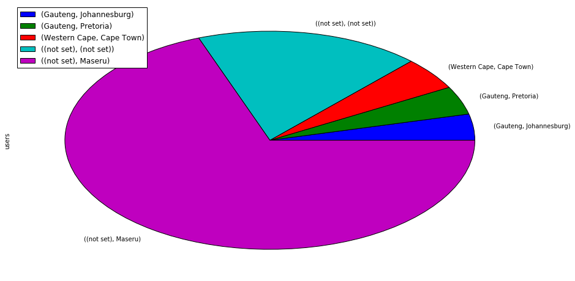

```python
#Top 5 region and city combinations
usersPerCity.tail().plot.pie(subplots=True, figsize=(15, 8))
```

### A similar analysis of one variable

```
array([<matplotlib.axes._subplots.AxesSubplot object at 0x1188f6c10>], dtype=object)
```

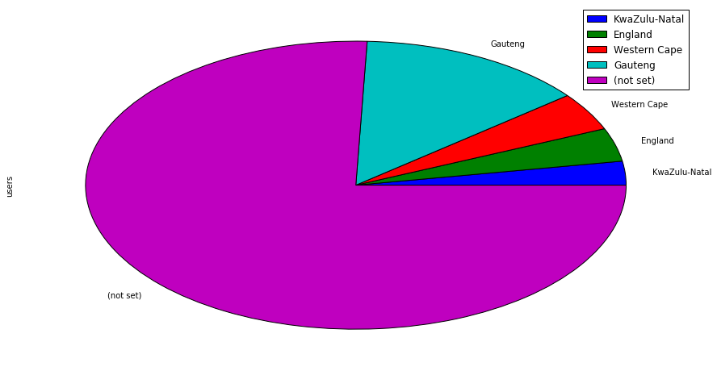

```python
usersPerRegion = df2[['users', 'region']].groupby(['region']).sum().sort_values(by='users')
usersPerRegion.tail().plot.pie(subplots=True,figsize=(15,8))
```

### In order to figure out new users each day:

- Create a typed date field in order to use default time-series behavior
- Create a new table using the same methods as before
- Use `.plot()` for the visualization with no arguments as time-series line graphs are the default

```python
df['date'] = pd.to_datetime(df['date'],infer_datetime_format=True)#format="%y-%m-%d")
df['date']
newUsersPerDay = df[['newUsers','date','users']].groupby('date', as_index=True).sum()
newUsersPerDay
```

| date | newUsers | users |
| --- | --- | --- |
| 2016-06-18 | 5 | 19 |
| 2016-06-19 | 2 | 10 |
| 2016-06-20 | 7 | 39 |
| 2016-06-21 | 0 | 34 |
| 2016-06-22 | 2 | 62 |
| 2016-06-23 | 12 | 94 |
| 2016-06-24 | 1 | 87 |
| 2016-06-25 | 5 | 32 |
| 2016-06-26 | 3 | 28 |
| 2016-06-27 | 5 | 54 |
| 2016-06-28 | 5 | 80 |
| 2016-06-29 | 1 | 50 |
| 2016-06-30 | 2 | 44 |
| 2016-07-01 | 14 | 55 |
| 2016-07-02 | 1 | 9 |
| 2016-07-03 | 0 | 6 |
| 2016-07-04 | 6 | 81 |
| 2016-07-05 | 4 | 43 |
| 2016-07-06 | 4 | 25 |
| 2016-07-07 | 6 | 66 |
| 2016-07-08 | 3 | 25 |
| 2016-07-09 | 2 | 7 |
| 2016-07-10 | 4 | 5 |
| 2016-07-11 | 6 | 30 |
| 2016-07-12 | 11 | 50 |
| 2016-07-13 | 2 | 32 |
| 2016-07-14 | 3 | 22 |
| 2016-07-15 | 29 | 114 |
| 2016-07-16 | 31 | 110 |
| 2016-07-17 | 27 | 76 |
| 2016-07-18 | 100 | 440 |

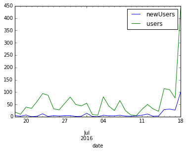

```python
newUsersPerDay.plot()
```

### Answering the devices and OSs question

- Create a new table with the desired data
- `.plot()`!

```
array([<matplotlib.axes._subplots.AxesSubplot object at 0x1189fc0d0>], dtype=object)
```

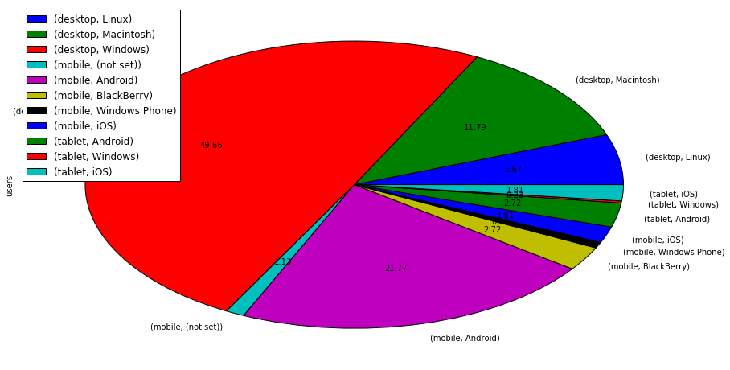

```python
devicesAndCategories = df2[['deviceCategory', 'operatingSystem', 'users']].groupby(['deviceCategory', 'operatingSystem']).sum()
devicesAndCategories.plot.pie(subplots=True, figsize=(15, 8), autopct='%.2f')
```

### With one variable

```
array([<matplotlib.axes._subplots.AxesSubplot object at 0x119834150>], dtype=object)
```

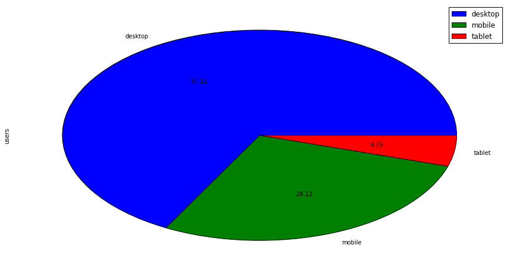

```python
df2[['deviceCategory','users']].groupby(['deviceCategory']).sum().plot.pie(subplots=True, figsize=(15,8), autopct='%.2f')
```

### Your boss: "That's too much data! Can I just look at desktop users?"

#### You: "Yes, of course"

### How?

- Select conditions: `.isin()`
- Use `autopct=` to show percentages on the chart

```
array([<matplotlib.axes._subplots.AxesSubplot object at 0x119b48c90>], dtype=object)
```

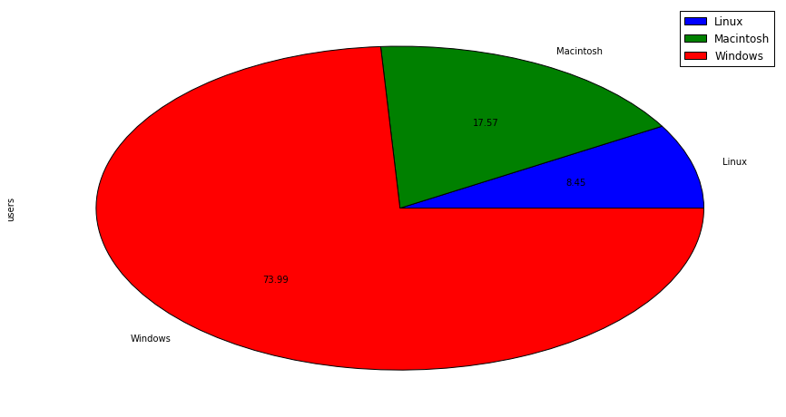

```python
desktopBrowserAndOS = df2[df2['deviceCategory'].isin(['desktop'])][['browser', 'users', 'operatingSystem']]
desktopBrowserAndOS.groupby(['operatingSystem']).sum().plot.pie(subplots=True, figsize=(15,8), autopct='%.2f')
```

### Your boss: "What browsers are they using on desktops?"

#### You: "Got it!"

```
array([<matplotlib.axes._subplots.AxesSubplot object at 0x118a121d0>], dtype=object)
```

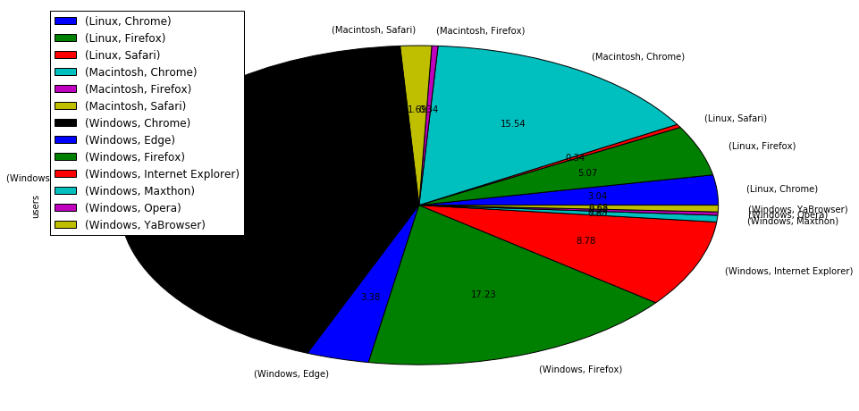

```python
desktopBrowserAndOS.groupby(['operatingSystem', 'browser']).sum().plot.pie(subplots=True, figsize=(15,8), autopct='%.2f')
```

### Your boss: "...just browsers?"

```
array([<matplotlib.axes._subplots.AxesSubplot object at 0x119f843d0>], dtype=object)
```

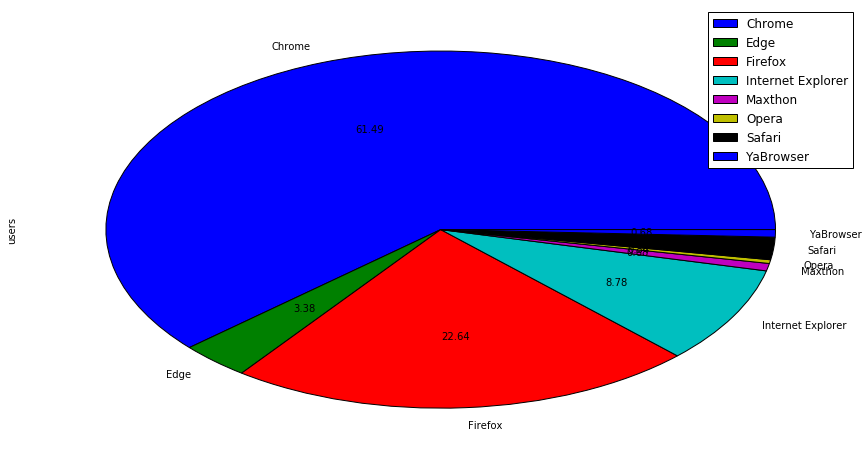

```python
desktopBrowserAndOS.groupby(['browser']).sum().plot.pie(subplots=True, figsize=(15,8), autopct='%.2f')
```